# Case2

Douglas Yip

11/17/2021

# Frito Lay HR Attrition

## Executive Summary

#### The purpose of this review is to provide Frito Lay Talent Management Team an iterative process with developing and retaining employees. The insights to this analysis are based on the data that was shared by Frito Lay that includes workforce planning, employee training programs, identifying high-potential employees and reducing/preventing voluntary employee turnover (attrition). We will provide a series of recommendations that identify potential opportunites to improve attrition.

## Recommendation

#### We recommend that your company to reevaluate 3 things to reduce your attrition rate. We recommend your teams to action against the following;

#### 1 - Re-evaluate your Travel program for associates who travel frequently - Create a survey to identify how often is the travel, how long are the trips and incentives vs industry?

#### 2 - Re-evaluate your Overtime policies to ensure equitable working conditions and wage - Investigate into potentials issues like forced overtime, reasons why people work overtime, and comparison vs industry

#### 3 - Comp and Ben team to review job description and wage requirements - Evaluate your low band levels like Sales associates and Research Scientist and compare to industry

```r
#create dataload and clean data
dfhr <- read_csv("https://raw.githubusercontent.com/dk28yip/6306_EDACase2/main/CaseStudy2-data.csv", show_col_types = FALSE)
dfhr$Department[dfhr$Department == "Research & Development"] <-"R&D"
dfhr$Department[dfhr$Department == "Human Resources"] <-"HR"
#add different columns to data set
dfhr$AttritionValue<-ifelse(dfhr$Attrition=="Yes",1,0) #Convert to numberic 1,0
dfhr$OverTimeValue<-ifelse(dfhr$OverTime=="Yes",1,0) #Convert to numberic 1,0
dfhr$MonthlyIncome_Factor <- cut(dfhr$MonthlyIncome, breaks = c(-0.1,5000,10000,15000,30000), labels = c("0-4.99","5-9.99","10-14.99",">15")) #Create Groups
dfhr$YearAtCompany_Factor <- cut(dfhr$YearsAtCompany, breaks = c(-5,4,8,12,40), labels = c("0-4","5-8","9-12","+12")) #Create Groups
```

### What type of distribution do we observe based on tenure and wage? Where could we potentially focus on reducing turnover?

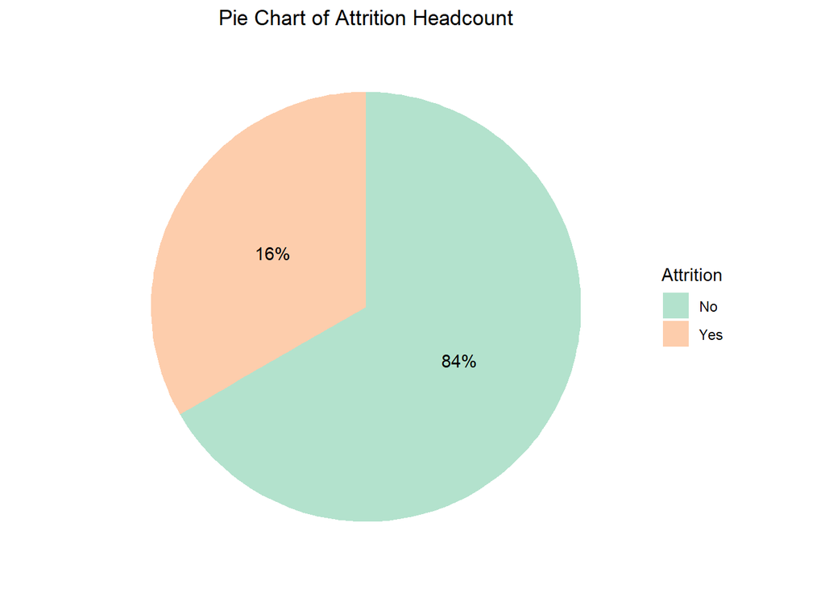

```r
#Attrition total
dfhr %>% count(Attrition, sort = T) %>% mutate(percentage = str_c(round(n / sum(n) * 100, 0), "%")) %>% ggplot(aes(x="", y=percentage,fill=Attrition)) + geom_bar(stat="identity", width=1) + coord_polar("y", start=0) + scale_fill_brewer(palette = "Pastel2") + geom_text(aes(label = paste(percentage)), position = position_stack(vjust = 0.5)) + theme_classic() + theme(plot.title = element_text(hjust=0.5), axis.line = element_blank(), axis.text = element_blank(), axis.ticks = element_blank()) + labs(fill = "Attrition", x = NULL, y = NULL, title = "Pie Chart of Attrition Headcount")
```

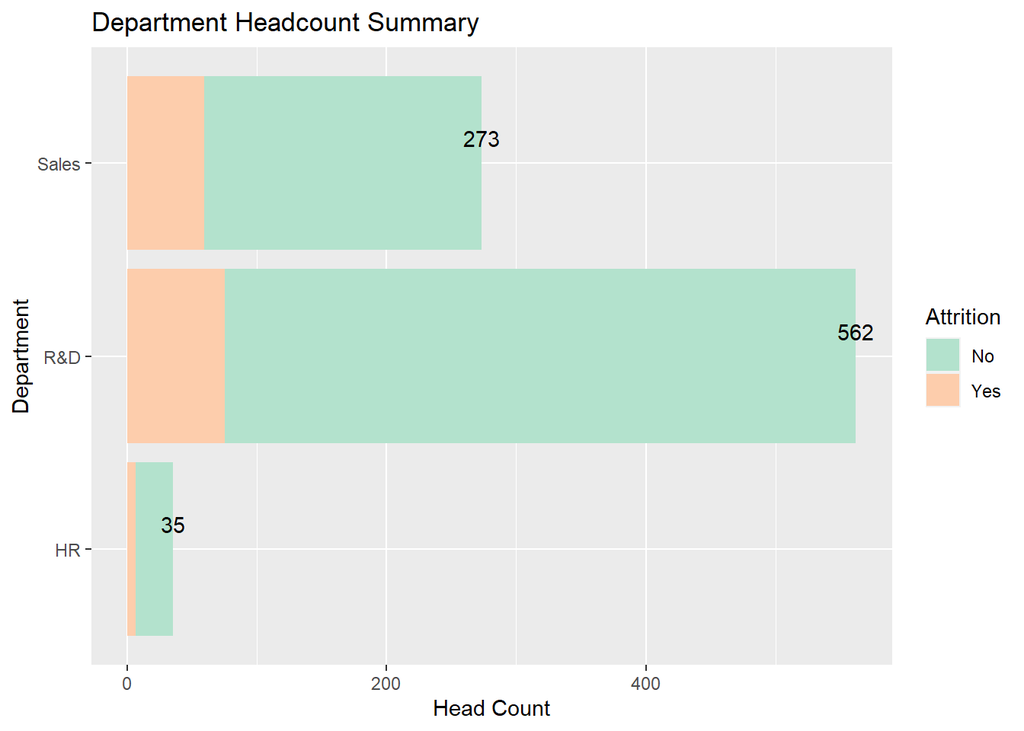

```r
#Attrition by department
dfhr %>% group_by(Department, Attrition) %>% summarize(hrsum=n()) %>% ggplot(aes(fill = Attrition, x=Department, y=hrsum)) + geom_bar(position="stack", stat="identity") + ggtitle("Department Headcount Summary") + xlab("Department") + ylab("Head Count")+ geom_text(aes(label = stat(y), group = Department), stat = 'summary', fun = sum, vjust = -1) + scale_fill_brewer(palette = "Pastel2") + coord_flip()
```

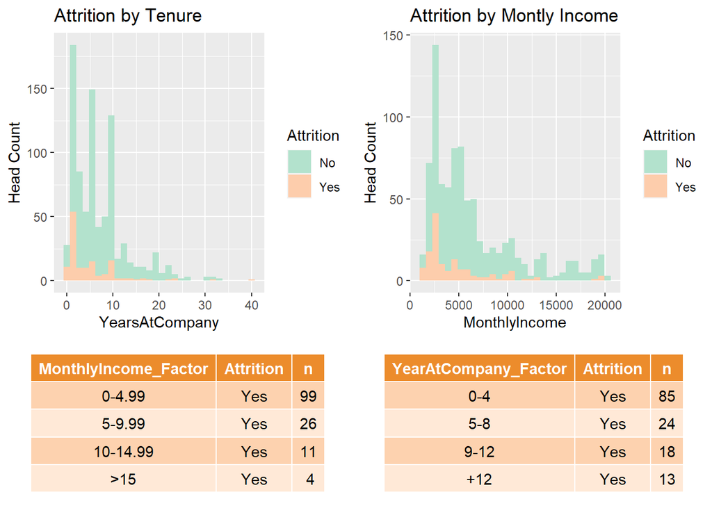

```r
#Attrition based on Income Levels
t1 <- dfhr %>% group_by(MonthlyIncome_Factor, Attrition) %>% filter(Attrition == "Yes") %>% count(Attrition, sort = T)
t1.p <- ggtexttable(t1, rows = NULL,theme = ttheme("mOrange"))

#Attrition based on Tenure
t2 <- dfhr %>% group_by(YearAtCompany_Factor, Attrition) %>% filter(Attrition == "Yes") %>% count(Attrition, sort = T)
t2.p <- ggtexttable(t2, rows = NULL,theme = ttheme("mOrange"))

#plot histogram of the tenure folks by attrition
p1.p <- dfhr %>% ggplot(aes(fill = Attrition, x = YearsAtCompany)) + geom_histogram(bins = 30) + scale_fill_brewer(palette = "Pastel2") + ggtitle("Attrition by Tenure") + ylab("Head Count")

#plot histogram of income level by attrition
p2.p <- dfhr %>% ggplot(aes(fill = Attrition, x = MonthlyIncome)) + geom_histogram(bins = 30) + scale_fill_brewer(palette = "Pastel2") + ggtitle("Attrition by Montly Income") + ylab("Head Count")

#group plots into one
ggarrange(p1.p,p2.p,t1.p,t2.p, ncol =2, nrow =2,heights = c(1, 0.5))
```

#### We see an unbalance dataset where we have 16% of the associates tagged as leaving the company. We have mainly R&D associates at a 562 count and Sales at a 273 count. Given that FritoLay is a Fortune 500 Consumer Packages Goods Company, this datasets seems unreasonable outcome of attrition but we will continue our study to idenitify opportunities.

```r
#We cleaned a data set to exclude outliers to study the data more carefully
dfhr_clean <- dfhr %>% filter(MonthlyIncome < 10000) %>% filter(YearsAtCompany <12)
```

### Does work-life balance of an associate impact the reason why people leave the organization?

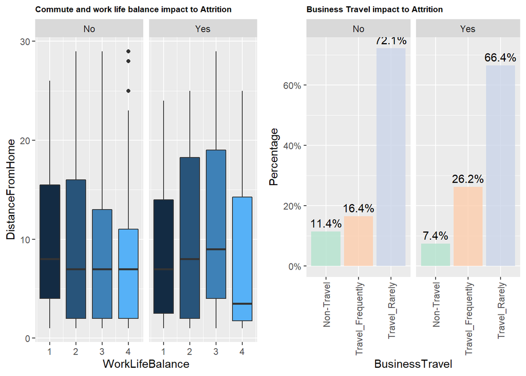

```r
#Create Attrition box plot given work life balance and distance from home
p3.p <- dfhr_clean %>% ggplot(aes(x= WorkLifeBalance, y=DistanceFromHome, group = WorkLifeBalance, fill = WorkLifeBalance)) + geom_boxplot() + theme(legend.position="none",plot.title = element_text(size = 8, face = "bold")) + facet_wrap(~ Attrition) + ggtitle("Commute and work life balance impact to Attrition")

#Create % Attrition bar graph given travel status
p4.p <- dfhr_clean %>% ggplot(aes(x= BusinessTravel, group=Attrition)) + geom_bar(aes(y = ..prop.., fill = factor(..x..)), stat="count", alpha = 0.8) + geom_text(aes(label = scales::percent(..prop..), y = ..prop.. ), stat= "count", vjust = -.5) + labs(y = "Percentage", fill="Business Travel") + facet_grid(~Attrition) + scale_y_continuous(labels=percent) + theme(legend.position = "none",plot.title = element_text(size = 8, face = "bold")) + ggtitle("Business Travel impact to Attrition") + scale_fill_brewer(palette = "Pastel2") + theme(axis.text.x = element_text(angle = 90, vjust = 0.5, hjust = 1))


#group plots into one
ggarrange(p3.p,p4.p, ncol =2, nrow =1)
```

##However, we observed a significantly higher level of attrition for individuals that are traveling frequently. Recommendation is reevaluate your travel policies to ensure that associates maintain worklife balance and to limit the turnover with the traveling population.

### Based on what we know on work life balance, do individuals working overtime impact an associates decision to leave the company?

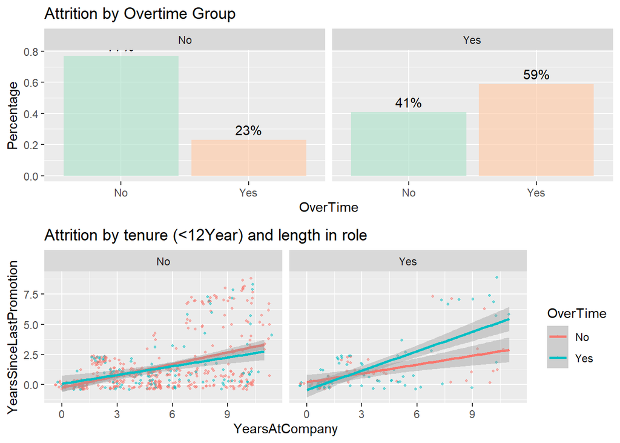

```r
#look at Overtime by attrition
p5.p <- dfhr_clean %>% ggplot(aes(x = OverTime, group = Attrition)) + geom_bar(aes(y = ..prop.., fill = factor(..x..)), stat="count", alpha = 0.7) + geom_text(aes(label = scales::percent(..prop..), y = ..prop.. ), stat= "count", vjust = -.5) + labs(y = "Percentage", fill= "OverTime") + facet_grid(~Attrition) + scale_fill_brewer(palette = "Pastel2") + theme(legend.position = "none") + ggtitle("Attrition by Overtime Group")

#look at tenure and length in role in respects to overtime and attrition
p6.p <- dfhr_clean %>% ggplot(aes(y = YearsSinceLastPromotion, x = YearsAtCompany, colour = OverTime)) + geom_jitter(size = 0.8, alpha = 0.5) + geom_smooth(method = "lm") + facet_wrap(~ Attrition) + ggtitle("Attrition by tenure (<12Year) and length in role") + scale_fill_brewer(palette = "Pastel2")

ggarrange(p5.p,p6.p, ncol =1, nrow =2)
```

#### Overtime Status significantly impacts an associates reasons to leave. In addition, we observe the longer one stays in one role for a longer period time that requires overtime, the greater the likelyhood to quitting vs the ones that don’t have to work overtime. We recommend that HR re-evaluate your mandatory overtime practices to ensure that employees don’t quit due to burn out.

### Is there a particular department or role that over indexes in attrition vs others?

### Where are we seeing the most attrition by Department and Role?

```r
#Create User defined Function.
#Proportions features VS Attrition Function

bar_plot_proportions <- function(feature, target){

  varCat <- as_label(enquo(feature))
  varCat <- str_to_title(str_replace(varCat, "_", " "))

  if(missing(target)) {
    prop_data <- dfhr_clean %>%
      group_by({{feature}}) %>%
      summarise(n = n(), .groups = "drop") %>%
      ungroup() %>%
      mutate(percent = str_c(round(n/sum(n)*100,0),"%"),
             just = n/4,
             VarName = fct_reorder(factor({{feature}}), n ),
             label_hjust = case_when(
                  n < quantile(n, probs = 0.85) ~ -0.2,
                  TRUE ~ 1.1,
                ),
             label_color = case_when(
                  n < quantile(n, probs = 0.85) ~ "black",
                  TRUE ~ "white",
                ))

    ggplot(prop_data, aes(x = VarName, y = n, fill = VarName)) +
      geom_col(width = 0.7,
               size = 1,
               show.legend = FALSE) +
      coord_flip() +
      geom_text(show.legend = FALSE,
                aes(y = n, label = str_c(percent,n, sep = " "), hjust = label_hjust,
                    color = label_color) ,
                size = 2.5
      ) +
      scale_y_continuous(expand = expansion(add = c(50, max(prop_data$just)))) +
      scale_fill_viridis_d(direction = -1) +
      scale_color_manual(values = c("black", "white")) +
      theme(
        legend.position = "right",
        plot.background = element_rect(colour = "gray"),
        plot.title.position = "panel",
        plot.title = element_text(size = 10, hjust = 0.5),
        plot.subtitle = element_text(size = 8),
        plot.caption.position = "plot",
        plot.caption = element_text(size = 6, color = "grey"),
        panel.grid = element_blank(),
        axis.text.x = element_blank(),
        axis.ticks.x = element_blank(),
        axis.text.y = element_text(size = 8)
      ) +
      labs(
        title = NULL,
        subtitle = NULL,
        x = NULL,
        y = NULL
      )

  }
  else {

    prop_data <- dfhr_clean %>%
      group_by({{feature}},{{target}}) %>%
      summarise(n = n(), .groups = "drop") %>%
      ungroup() %>%
      mutate(percent = str_c(round(n/sum(n)*100,0),"%"),
             just = n/4,
             VarName = reorder_within(factor({{feature}}), n, {{target}}),
             label_hjust = case_when(
                  n < quantile(n, probs = 0.85) ~ -0.2,
                  TRUE ~ 1.1,
                ),
             label_color = case_when(
                  n < quantile(n, probs = 0.85) ~ "black",
                  TRUE ~ "white",
                ))

    ggplot(prop_data, aes(x = VarName, y = n, fill = VarName)) +
      geom_col(width = 0.7,
               size = 1,
               show.legend = FALSE) +
      coord_flip() +
      geom_text(show.legend = FALSE,
                aes(y = n, label = str_c(percent,n, sep = " "), hjust = label_hjust,
                    color = label_color) ,
                size = 2.5
      ) +
      facet_wrap(vars({{target}}), scales = "free_y")+
      scale_y_continuous(expand = expansion(add = c(10, max(prop_data$just)))) +
      scale_x_reordered() +
      scale_fill_viridis_d(direction = -1) +
      scale_color_manual(values = c("black", "white")) +
      theme(
        legend.position = "right",
        strip.background = element_rect(fill = "#CD3B16"),
        strip.text = element_text(color = "white", face = "bold", size = 8),
        plot.background = element_rect(colour = "gray"),
        plot.title.position = "panel",
        plot.title = element_text(size = 10, hjust = 0.5),
        plot.subtitle = element_text(size = 8),
        plot.caption.position = "plot",
        plot.caption = element_text(size = 6, color = "grey"),
        panel.grid = element_blank(),
        axis.text.x = element_blank(),
        axis.ticks.x = element_blank(),
        axis.text.y = element_text(size = 6)
      ) +
      labs(
        title = glue("{varCat} VS Attrition"),
        subtitle = NULL,
        x = NULL,
        y = NULL
      )
  }

}
```

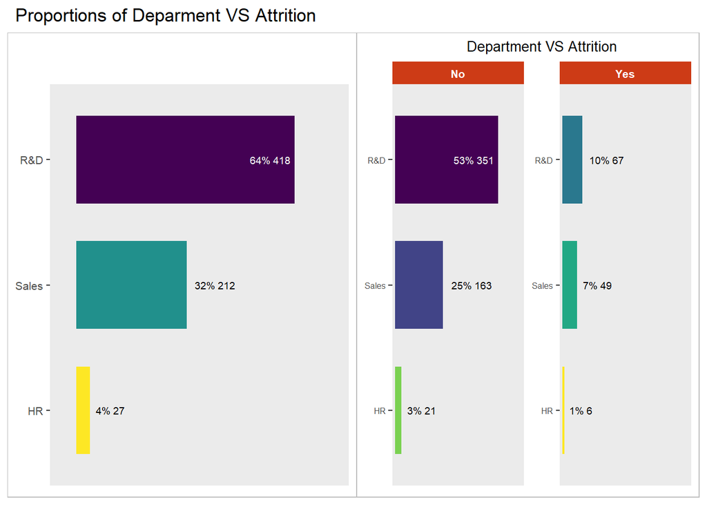

```r
plt_Department <- bar_plot_proportions(Department)
plt_Department_att <- bar_plot_proportions(Department, Attrition)

(plt_Department +
   plt_Department_att)+
  plot_annotation(
  title = "Proportions of Deparment VS Attrition",
) &
  theme(plot.caption = element_text(size = 7))
```

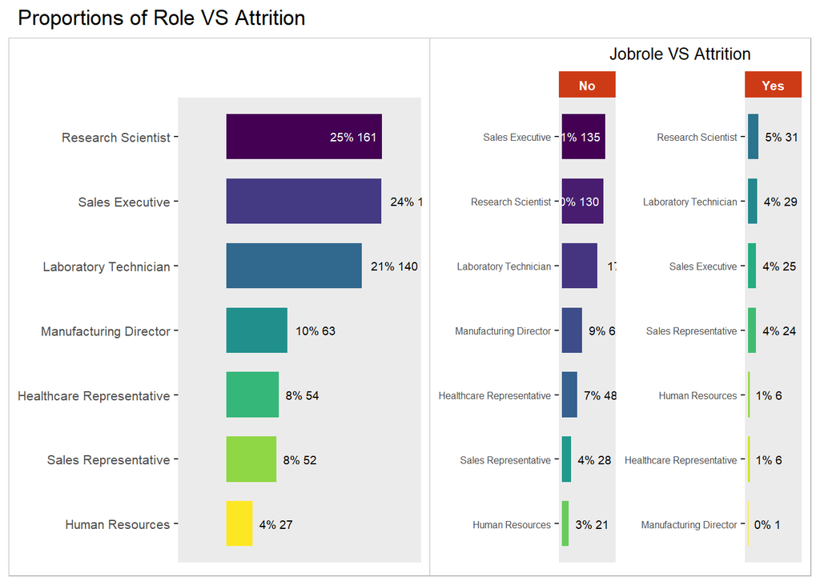

```r
plt_JobRole <- bar_plot_proportions(JobRole)
plt_JobRole_att <- bar_plot_proportions(JobRole, Attrition)

(plt_JobRole +
   plt_JobRole_att)+
  plot_annotation(
  title = "Proportions of Role VS Attrition",
) &
  theme(plot.caption = element_text(size = 7))
```

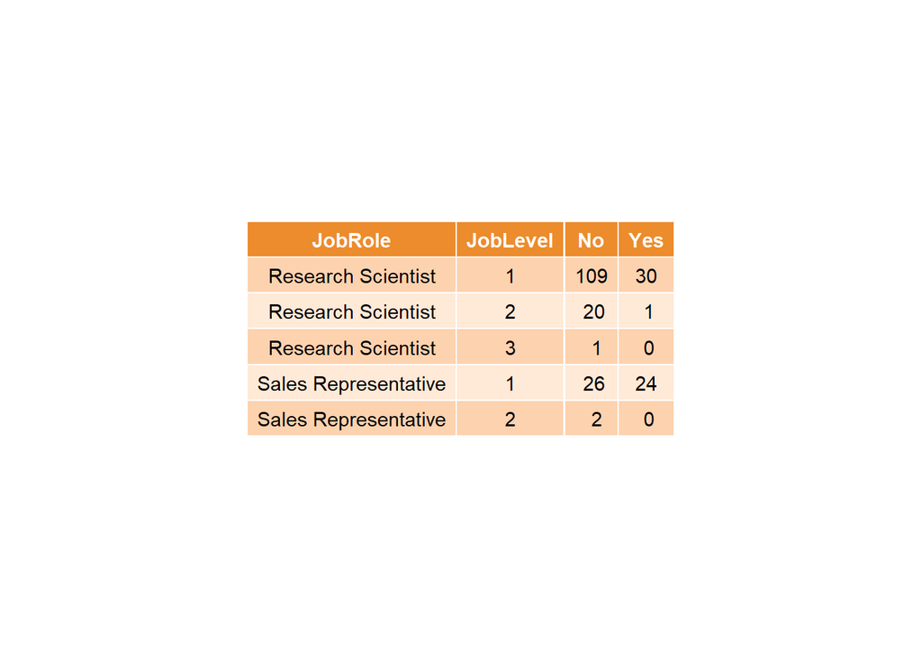

```r
JobLevelChart <- dfhr_clean %>% group_by(Attrition,JobRole, JobLevel) %>% filter(JobRole == "Research Scientist" | JobRole =="Sales Representative") %>%  count(Attrition, sort = T)
JobLevelChart2 <- spread(JobLevelChart,Attrition,n) #create summary table of roles
JobLevelChart2[is.na(JobLevelChart2)] <- 0 #sort table
ggtexttable(JobLevelChart2,rows = NULL,theme = ttheme("mOrange"))  #create theme for table
```

### Based on our knowledge about attrition, we will determine which model will give us a specificity and sensitivity of >60%.

```r
#Determine the training sets to be used in model.
set.seed(128)
splitPerc = .75
filterdfhr <- dfhr %>% select(Attrition, MonthlyIncome, OverTimeValue, JobLevel, YearsAtCompany)

train1 = sample(1:dim(filterdfhr)[1],round(splitPerc * dim(filterdfhr)[1])) #dim(filterdfhr)[1] will determine thte total number of rows
train = filterdfhr[train1,]
test = filterdfhr[-train1,]


#knn = 3
modelknn = knn(train[,c(2,3,4,5)],test[,c(2,3,4,5)],train$Attrition, prob = TRUE, k = 3) #confusion matrix
confusionMatrix(table(modelknn,test$Attrition))
```

```
## Confusion Matrix and Statistics
##
##
## modelknn  No Yes
##      No  166  33
##      Yes  15   4
##
##                Accuracy : 0.7798
##                  95% CI : (0.7189, 0.833)
##     No Information Rate : 0.8303
##     P-Value [Acc > NIR] : 0.97822
##
##                   Kappa : 0.0313
##
##  Mcnemar's Test P-Value : 0.01414
##
##             Sensitivity : 0.9171
##             Specificity : 0.1081
##          Pos Pred Value : 0.8342
##          Neg Pred Value : 0.2105
##              Prevalence : 0.8303
##          Detection Rate : 0.7615
##    Detection Prevalence : 0.9128
##       Balanced Accuracy : 0.5126
##
##        'Positive' Class : No
##
```

```r
#Naives Bayes
modelnb = naiveBayes(train[,c(2,3,4,5)],train$Attrition)
confusionMatrix(table(predict(modelnb,test[,c(2,3,4,5)]),test$Attrition))
```

```
## Confusion Matrix and Statistics
##
##
##        No Yes
##   No  166  19
##   Yes  15  18
##
##                Accuracy : 0.844
##                  95% CI : (0.7889, 0.8895)
##     No Information Rate : 0.8303
##     P-Value [Acc > NIR] : 0.3318
##
##                   Kappa : 0.4218
##
##  Mcnemar's Test P-Value : 0.6069
##
##             Sensitivity : 0.9171
##             Specificity : 0.4865
##          Pos Pred Value : 0.8973
##          Neg Pred Value : 0.5455
##              Prevalence : 0.8303
##          Detection Rate : 0.7615
##    Detection Prevalence : 0.8486
##       Balanced Accuracy : 0.7018
##
##        'Positive' Class : No
##
```

#### Based on the analytics, we will utilize Montly Income, OverTime status, Job Level and Years as our Predictors to attrition.

#### We utilize these variables for both the KNN and Naive Bayes predictive model. The predicting model that best predicts whiles achieving a good balance of sensitivity and specificity is the Naive Bayes Model with 92% Sensitivity and 49% Specificity. In addition, accruacy of the model predicting No Attrition was at 84%.

### Assuming that these variables are reasons why people leave, is this a good predictor for income. We will use a multi linear regression model to determine whether a RMSE of <3000 is achieved.

```r
#Linear model
modellm <- lm(MonthlyIncome ~ YearsAtCompany + OverTimeValue + JobLevel, data = train)
summary(modellm)
```

```
##
## Call:
## lm(formula = MonthlyIncome ~ YearsAtCompany + OverTimeValue +
##     JobLevel, data = train)
##
## Residuals:
##     Min      1Q  Median      3Q     Max
## -4913.2  -947.7    73.2   690.1  3727.0
##
## Coefficients:
##                Estimate Std. Error t value Pr(>|t|)
## (Intercept)    -1756.58     123.07 -14.273   <2e-16 ***
## YearsAtCompany   -11.77      10.87  -1.083    0.279
## OverTimeValue    -26.75     123.16  -0.217    0.828
## JobLevel        4029.77      60.03  67.134   <2e-16 ***
## ---
## Signif. codes:  0 '***' 0.001 '**' 0.01 '*' 0.05 '.' 0.1 ' ' 1
##
## Residual standard error: 1406 on 648 degrees of freedom
## Multiple R-squared:  0.9051, Adjusted R-squared:  0.9047
## F-statistic:  2061 on 3 and 648 DF,  p-value: < 2.2e-16
```

```r
#calculate the RMSE of the Linear Model
sqrt(mean(modellm$residuals^2))
```

```
## [1] 1401.281
```

## Recommendation

#### We recommend that your company to reevaluate 3 things to reduce your attrition rate. We recommend your teams to action against the following;

#### 1) Re-evaluate your Travel program for associates who travel frequently - Create a survey to identify how often is the travel, how long are the trips and incentives vs industry?

#### 2) Re-evaluate your Overtime policies to ensure equitable working conditions and wage - Investigate into potentials issues like forced overtime, reasons why people work overtime, and comparison vs industry

#### 3) Comp and Ben team to review job description and wage requirements - Evaluate your low band levels like Sales associates and Research Scientist and compare to industry